# Sentiment Analysis – Visualization

Asmik & Lisa – for Intro to NLP

April/May 2021

[figure not shown]

## Visualize Results of Sentiment Analysis

This demo is about **visualizing results of sentiment classification**.

We show how to visualize classification results in different ways, mostly using the `tidyverse` and `ggplot2` packages.

```r
# Load required packages

library(quanteda)
library(readr)
library(tidyverse)
library(tidytext)
library(wordcloud)
```

### Read data

As always, we start by **reading** the data. We will use data labeled with both sentiment polarities and topics, i.e., the result of topic modeling incl. interpretation and sentiment prediction.

```r
# path <- ... (individual file location)

data_labeled <- readr::read_delim(
  sprintf("%s/data_labeled_processed.csv", path),
  delim = ",",
  escape_double = FALSE,
  trim_ws = TRUE)
```

### Create barplots

With **barplots** we can nicely depict label distributions along various dimensions, e.g., time.

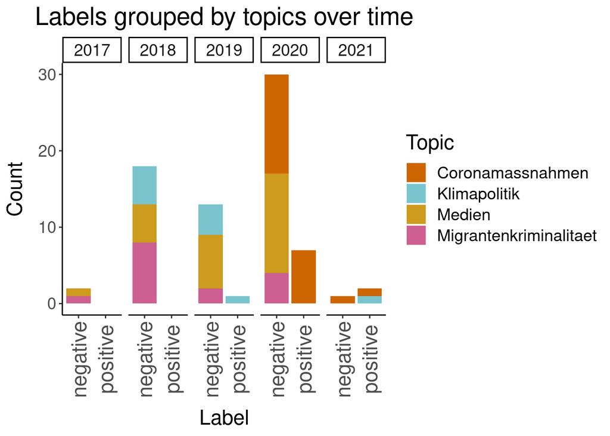

```r
# Extract year and save in a seperate column

data_labeled$year <- format(data_labeled$twitter_created_at, format = "%Y")

# Count tweets grouped by year, topic and label

labels_per_year <- data_labeled %>%
  dplyr::group_by(year, topic) %>%
  dplyr::count(label)

# Filter 4 topics to dive into more deeply

labels_per_year_filtered <- labels_per_year %>%
  dplyr::filter(topic %in% c(
    "Coronamassnahmen",
    "Medien",
    "Migrantenkriminalitaet",
    "Klimapolitik"))

# Create a grouped and stacked barplot

barplot_label_per_year <- ggplot2::ggplot(
  labels_per_year_filtered,
  aes(y = n, x = label, fill = topic)) +
  geom_bar(position = "stack", stat = "identity") +
  facet_grid(. ~ year) +
  ylab("Count") +
  xlab("Label") +
  theme_classic() +
  theme(
    text = element_text(size = 17),
    axis.text.x = element_text(angle = 90, size = 17, vjust = 0.5),
    axis.title.x = element_text(margin = margin(t = 10, r = 0, b = 0, l = 0)),
    axis.title.y = element_text(margin = margin(t = 0, r = 10, b = 0, l = 0)),
    legend.position = "right",
    plot.title = element_text(hjust = 0.5)) +
  scale_fill_manual(
    "Topic",
    values = c("darkorange3", "cadetblue3", "goldenrod3", "hotpink3")) +
  labs(title = "") +
  ggtitle("Labels grouped by topics over time")

barplot_label_per_year
```

Rather than over time, we can also show the label distribution by topic and color it according to sentiment:

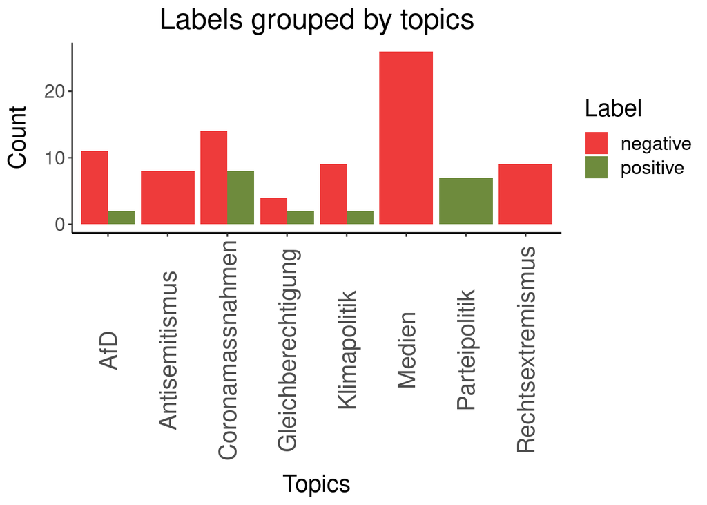

```r
# Count tweets grouped by topic and label

labels_per_topic <- data_labeled %>%
  dplyr::group_by(topic) %>%
  dplyr::count(label)

# Filter 9 topics to dive into more deeply

labels_per_topic_filtered <- labels_per_topic %>%
  filter(topic %in% c(
    "Antisemitismus",
    "AfD",
    "Coronamassnahmen",
    "Parteipolitik",
    "Coronapolitik",
    "Klimapolitik",
    "Rechtsextremismus",
    "Medien",
    "Gleichberechtigung"))

# Create a grouped and stacked

barplot_label_per_topic <- ggplot2::ggplot(
  labels_per_topic_filtered, aes(y = n, x = topic, fill = label)) +
  geom_bar(position = "dodge", stat = "identity") +
  ylab("Count") +
  xlab("Topics") +
  theme_classic() +
  theme(
    text = element_text(size = 17),
    axis.text.x = element_text(angle = 90, size = 17, vjust = 0.5),
    axis.title.x = element_text(margin = margin(t = 10, r = 0, b = 0, l = 0)),
    axis.title.y = element_text(margin = margin(t = 0, r = 10, b = 0, l = 0)),
    legend.position = "right",
    plot.title = element_text(hjust = 0.5)) +
  scale_fill_manual(
    "Label",
    values = c("brown2", "darkolivegreen4")) +
  labs(title = "") +
  ggtitle("Labels grouped by topics")

barplot_label_per_topic
```

### Create word clouds

As seen during topic modeling, we can use **word clouds** to visualize topic-word distribution. With the additional sentiment information we can also color them accordingly.

**Option 1:** via `quanteda`:

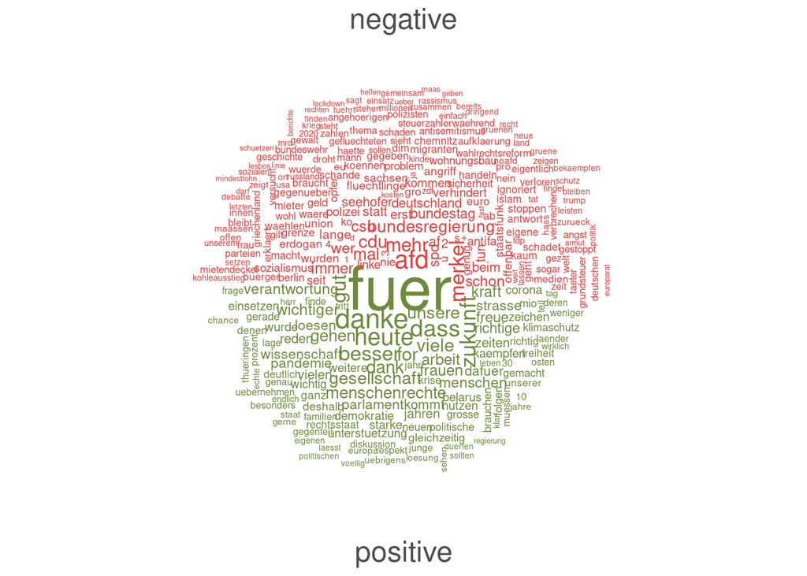

```r
# Create dfm

tkns <- quanteda::tokens(quanteda::corpus(
  data_labeled, text_field = "twitter_full_text"), remove_punct = TRUE) %>%
  quanteda::tokens_remove(quanteda::stopwords("de"))

dfm <- quanteda::dfm(tkns) %>%
  quanteda::dfm_group(label) %>%
  quanteda::dfm_trim(min_termfreq = 5)

# Plot word cloud

quanteda.textplots::textplot_wordcloud(
  dfm,
  comparison = TRUE,
  max_words = 300,
  adjust = 0.1,
  color = c("brown2", "darkolivegreen4"))
```

**Option 2:** via `tidytext` and `wordcloud`, this time for one selected topic:

```r
word_frequencies <- data_labeled %>%
  dplyr::mutate(linenumber = row_number()) %>%
  tidytext::unnest_tokens(word, twitter_full_text) %>%
  dplyr::anti_join(tidytext::get_stopwords(language = "de")) %>%
  dplyr::group_by(topic, label) %>%
  dplyr::count(word, sort = TRUE) %>%
  dplyr::mutate(word = reorder(word, n)) %>%
  dplyr::ungroup()
topic_name <- "AfD"

word_frequencies_filtered_topic <- word_frequencies %>%
  filter(topic == topic_name) %>%
  top_n(20) %>%
  mutate(color = ifelse(label == "positive", "darkolivegreen4", "brown2"))
```

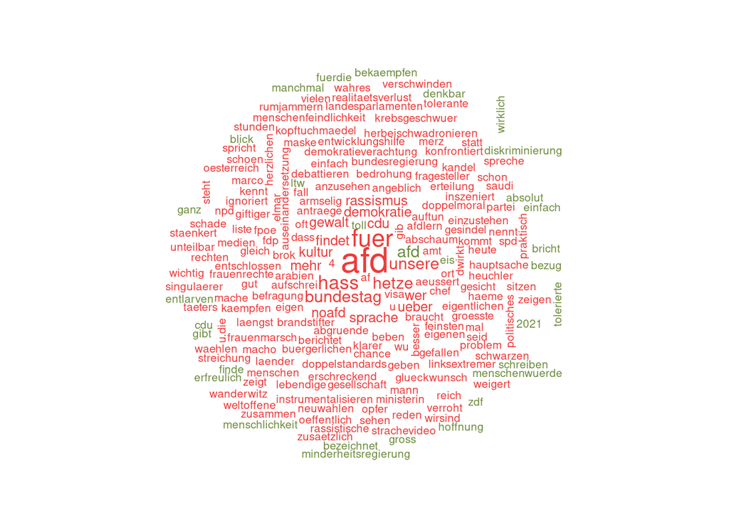

```r
wordcloud::wordcloud(
  words = word_frequencies_filtered_topic$word,
  freq = word_frequencies_filtered_topic$n,
  min.freq = 1,
  max.words = 200,
  ordered.colors = TRUE,
  random.order = FALSE,
  scale = c(2, 0.5),
  rot.per = 0.1,
  colors = word_frequencies_filtered_topic$color)
```

Alternatively, we can visualize **word frequencies** like this:

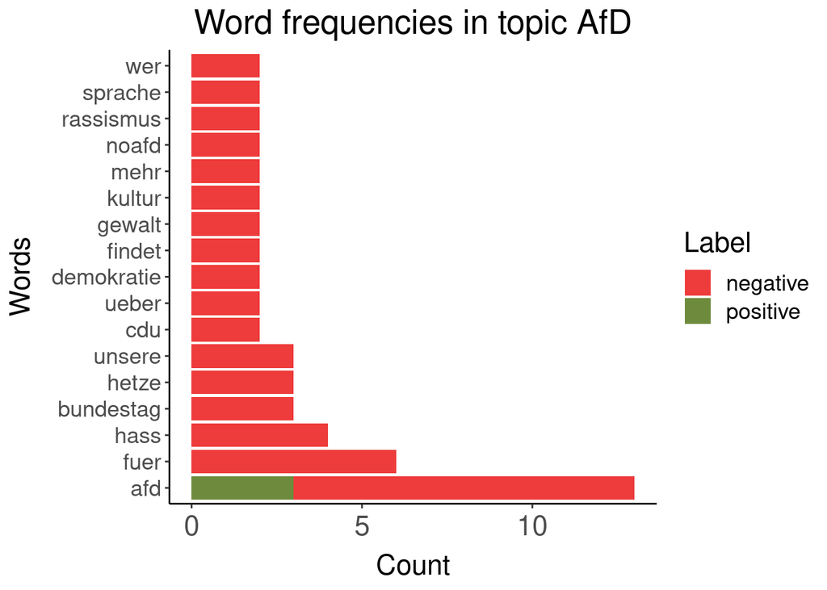

```r
word_frequencies_filtered_topic %>%
  dplyr::mutate(word = reorder(word, n)) %>%
  dplyr::filter(n > 1) %>%
  ggplot2::ggplot(aes(reorder(word, -n), n, fill = label)) +
  geom_col() +
  xlab(NULL) +
  coord_flip() +
  ylab("Count") +
  xlab("Words") +
  theme_classic() +
  theme(
    text = element_text(size = 17),
    axis.text.x = element_text(size = 17, vjust = 0.5),
    axis.title.x = element_text(margin = margin(t = 10, r = 0, b = 0, l = 0)),
    axis.title.y = element_text(margin = margin(t = 0, r = 10, b = 0, l = 0)),
    legend.position = "right",
    plot.title = element_text(hjust = 0.5)) +
  scale_fill_manual("Label", values = c("brown2", "darkolivegreen4")) +
  labs(title = "") +
  ggtitle(paste0("Word frequencies in topic ", topic_name))
```

**Obviously, there are infinitely more possibilities for visualizing results. Maybe this helps for a little inspiration!**